# Figure 1

- This code makes all input figures for Figure 1 of Gardner et. al. Controbution of Retrotransposition to Developmental Disorders (2018)
- All Figures need some cleaning up and processing in Illustrator
- All files/code are located in: `/Users/eg15/Documents/Current Projects/DDD/Manuscript/Figures/Figure1/`
- All scripts to generate raw data are located in: `/lustre/scratch115/projects/ddd/users/eg15/WXS_10K/VCF/VCF_v6/vep/`
- There are 2 versions of the data in Fig1. One for MEIs outside of bait regions, and the other for MEIs within bait regions. The main text figures are here, for the others (includign supplemental figure 8), go to the supplemental notebook.

## Startup Code

Load neccessary libraries for this notebook to work and setup basic stuff:

- Read in sample name key
- default graphpad-like theme
- colour palette which includes MEI/SNV colours in order: Alu, L1, SVA, PPG, All, SNV

## Allele frequency plot for figure 1F

Quick script to generate MEI files necessary for this project at : `/lustre/scratch115/projects/ddd/users/eg15/WXS_10K/VCF/VCF_v6/vep/get_AF.sh`

- This script runs code like: vcftools –gzvcf ALU.vep_annotated.dupes_indv_removed.vcf.gz –keep parents_dddp.unaffected.txt –freq –out ALU –mac 1
- Files generated are:
  - <MEI_NAME>.frq

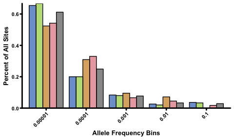

```r
##Set Colour palette
cPalette <- c("#7DA1D4","#BEDE85","#DCB070","#EAAAB0","#999999")
##Import all files
ALU <- data.table(read_delim("~/Documents/Current Projects/DDD/Manuscript/Figures/Figure1/RawData/ALU.frq","\t", escape_double = FALSE, col_names = FALSE, trim_ws = TRUE))
LINE1 <- data.table(read_delim("~/Documents/Current Projects/DDD/Manuscript/Figures/Figure1/RawData/LINE1.frq","\t", escape_double = FALSE, col_names = FALSE,trim_ws = TRUE))
SVA <- data.table(read_delim("~/Documents/Current Projects/DDD/Manuscript/Figures/Figure1/RawData/SVA.frq","\t", escape_double = FALSE, col_names = FALSE, trim_ws = TRUE))
## Get individual IDs and Genes from pseudogene vcf and count how many sites per individual/retrogene
RETROGENE <- data.table(geneid=pseudo_calls[,GENE],N=rowSums(pseudo_calls[,5:ncol(pseudo_calls)]))
total_indv<-ncol(pseudo_calls) - 4 ## minus 4 because of info columns
RETROGENE[,af:=N/total_indv]
RETROGENE[,af.cut:=cut(af,breaks= c(0.00001,0.0001,0.001,0.01,0.1,1))]
ALU[,ac:=apply(ALU,1,function(x) {v<-strsplit(x[6],":",fixed=TRUE);x<-round(as.numeric(v[[1]][4])*as.numeric(x[4]));if(x > 25) {25} else {x}})]
ALU[,af:=apply(ALU,1,function(x) {v<-strsplit(x[6],":",fixed=TRUE);as.numeric(v[[1]][4])})]
ALU[,af.cut:=cut(af,breaks= c(0.00001,0.0001,0.001,0.01,0.1,1))]
LINE1[,ac:=apply(LINE1,1,function(x) {v<-strsplit(x[6],":",fixed=TRUE);x<-round(as.numeric(v[[1]][4])*as.numeric(x[4]));if(x > 25) {25} else {x}})]
LINE1[,af:=apply(LINE1,1,function(x) {v<-strsplit(x[6],":",fixed=TRUE);as.numeric(v[[1]][4])})]
LINE1[,af.cut:=cut(af,breaks= c(0.00001,0.0001,0.001,0.01,0.1,1))]
SVA[,ac:=apply(SVA,1,function(x) {v<-strsplit(x[6],":",fixed=TRUE);x<-round(as.numeric(v[[1]][4])*as.numeric(x[4]));if(x > 25) {25} else {x}})]
SVA[,af:=apply(SVA,1,function(x) {v<-strsplit(x[6],":",fixed=TRUE);as.numeric(v[[1]][4])})]
SVA[,af.cut:=cut(af,breaks= c(0.00001,0.0001,0.001,0.01,0.1,1))]
ac<-data.frame(ac=c(ALU[,ac],LINE1[,ac],SVA[,ac]),mei=c(rep("Alu",nrow(ALU)),rep("LINE-1",nrow(LINE1)),rep("SVA",nrow(SVA))))
##Get AF Bins
bins <- data.table(data.table(table(ALU[,af.cut]))[,1])
bins[,ALU:=data.table(table(ALU[,af.cut]))[,2]]
bins[,LINE1:=data.table(table(LINE1[,af.cut]))[,2]]
bins[,SVA:=data.table(table(SVA[,af.cut]))[,2]]
bins[,Retrogene:=data.table(table(RETROGENE[,af.cut]))[,2]]
bins[,Total:=apply(bins,1,function(x){as.numeric(x[2])+as.numeric(x[3])+as.numeric(x[4])+as.numeric(x[5])})]
bins<-data.table(bins=c(bins[,V1],bins[,V1],bins[,V1],bins[,V1],bins[,V1]),
                 counts=c(bins[,ALU],bins[,LINE1],bins[,SVA],bins[,Retrogene],bins[,Total]),
                 MEI=c(rep("ALU",5),rep("LINE1",5),rep("SVA",5),rep("Retrogenes",5),rep("Total",5)))
bins[,pct:=counts/sum(counts),by=MEI]
bins<-data.frame(bins)
bins$MEI2<-factor(bins$MEI,levels=c("ALU","LINE1","SVA","Retrogenes","Total"))
bins$bins2<-factor(bins$bins,levels=c("(1e-05,0.0001]","(0.0001,0.001]","(0.001,0.01]","(0.01,0.1]","(0.1,1]"))
bins<-data.table(bins)
plot<-ggplot(bins,aes(bins2,pct,group=MEI2,fill=MEI2)) + scale_fill_manual(values=cPalette) + geom_col(position=position_dodge(width=0.85), width=0.85, colour="black", size=0.5) + scale_x_discrete(labels=c("0.00001","0.0001","0.001","0.01","0.1")) + scale_y_continuous(expand=c(0,0),breaks=c(0,0.2,0.4,0.6)) + theme + xlab("Allele Frequency Bins") + ylab("Percent of All Sites")
ggsave("~/Documents/Current Projects/DDD/Manuscript/Figures/Figure1/allele_count.pdf",plot=plot,width=3.5,height=2,units="in")
plot
```

## Allele count plot for figures 1A-E

Quick script to generate MEI files necessary for this project at : `/lustre/scratch115/projects/ddd/users/eg15/WXS_10K/VCF/VCF_v6/vep/get_indivTotals.sh`

```r
##Import all files
##Generated by (obviously change for MEI type):
##Script to run this automatically @ : /lustre/scratch115/projects/ddd/users/eg15/WXS_10K/VCF/VCF_v6/vep/get_indivTotals.sh
ALU_totals <- read_delim("~/Documents/Current Projects/DDD/Manuscript/Figures/Figure1/RawData/ALU.totals.txt","\t", escape_double = FALSE, col_names = FALSE,trim_ws = TRUE)
LINE1_totals <- read_delim("~/Documents/Current Projects/DDD/Manuscript/Figures/Figure1/RawData/LINE1.totals.txt","\t", escape_double = FALSE, col_names = FALSE,trim_ws = TRUE)
SVA_totals <- read_delim("~/Documents/Current Projects/DDD/Manuscript/Figures/Figure1/RawData/SVA.totals.txt","\t", escape_double = FALSE, col_names = FALSE,trim_ws = TRUE)

## Get individual IDs from pseudogene vcf and count how many sites per individual and remove dupe individuals
RETROGENE_totals<-data.table(ID=names(pseudo_calls[,5:ncol(pseudo_calls)]),"Retrogene"=colSums(pseudo_calls[,5:ncol(pseudo_calls)]))
RETROGENE_totals<-unique(merge(RETROGENE_totals,MEIAnalysisSamples_10K,by="ID",all.x=T,all.y=F),by="ID")
##Drop all uneccessary columns
RETROGENE_totals[,c("ID","EugeneID","BlackList","PctPaired","BaitVers","ProdYear","DecipherID","FamilyDecipherID")]=NULL
## Set any site with greater than 15 sites to NA... I DO NOT LIKE THIS
fix.outlier<-function(x) {
  if(x <= 15) {
    return(x)
  } else {
    return(NA)
  }
}

RETROGENE_totals[,Retrogene:=mapply(fix.outlier,Retrogene)]

strsplit.mod<-function(x,y) {
  z<-strsplit(x,y)
  return(z[[1]][2])
}

## Build totals across all 4 RIP classes for parents only
totals <- data.table(ID = ALU_totals$X1, "Alu" = ALU_totals$X2,"LINE-1" = LINE1_totals$X2, "SVA" = SVA_totals$X2)
totals <- merge(totals,RETROGENE_totals,by.x="ID",by.y="DDDPID")
totals <- totals[,Total:=rowSums(totals[,2:5],na.rm = T)]
totals <- merge(totals,MEIAnalysisSamples_10K[,c("DDDPID","DecipherID")],by.x="ID",by.y="DDDPID",all.y=F)
totals <- unique(totals)
totals[,DecipherID:=mapply(strsplit.mod,DecipherID,":")]
# Only use this if we want to remove child samples:
# totals<-totals[!is.na(DecipherID)]
tr<-nrow(totals)
totals <- data.table("indv" = rep(totals[,ID],"5"), "total" = c(totals[,Alu],totals[,`LINE-1`],totals[,SVA],totals[,Retrogene],totals[,Total]), "mei"=c(rep("Alu",tr),rep("L1",tr),rep("SVA",tr),rep("PPGs",tr),rep("Total",tr)))
totals[,mei:=factor(totals[,mei],levels=c("Alu","L1","SVA","PPGs","Total"))]

plot<-ggplot(totals,aes(total,fill=mei)) + scale_fill_manual(values=cPalette) + geom_histogram(binwidth=1,colour="black",size=0.25) + facet_wrap(~ mei, scales="free", nrow=1) + xlab("Ascertained MEIs / Individual Exome") + ylab("# of Individuals") + scale_y_continuous(expand=c(0,0)) + theme
ggsave(paste("~/Documents/Current Projects/DDD/Manuscript/Figures/Figure1/count_histrograms.pdf",sep=""),plot=plot,width=7,height=2,units="in")
plot
```

[output not shown]

### Poisson plots

Plots with the Poisson dist. overlayed over each MEI in order Alu, L1, SVA, PPG, Total

These are not included in the manuscript *per se* but a statement is made stating that all the distributions fit a Poisson distribution.

```r
#This code will plot Poisson distribution over each histogram.
##Looks kind of ugly and do not use in primary figure.

mei.types<-c("Alu","L1","SVA","PPGs","Total")
plot.table<-data.table(mei=c("Alu","L1","SVA","PPGs","Total"),colour=cPalette)

draw.graph<-function(current.mei,current.col) {

  mean.mei<-totals[mei==current.mei,mean(total,na.rm=T)]
  pois<-data.table(table(rpois(17031,mean.mei)))

  testing<-data.table(table(totals[mei==current.mei,total]))
  testing<-merge(pois,testing,by="V1",all.x=T,all.y=T)
  setnames(testing,names(testing),c("count","pois","mei"))

  plot<-ggplot(testing,aes(x=as.numeric(count))) + scale_x_continuous() + geom_col(aes(y=mei),fill=current.col,colour="black",size=0.25) + geom_point(aes(y=pois),colour="blue") + scale_y_continuous(expand=c(0,0)) + xlab("Total Sites") + ylab(NULL) + theme
  return(list(plot))

}
plot.table[,graph:=mapply(draw.graph,mei,colour)]
plot.table[mei=="Alu",graph][[1]]
plot.table[mei=="L1",graph][[1]]
plot.table[mei=="SVA",graph][[1]]
plot.table[mei=="PPGs",graph][[1]]
plot.table[mei=="Total",graph][[1]]
```

[output not shown]

### Vertical allele per individual plots for presentation

```r
##Now do vertical version for presentations:
theme.vertical<-theme+theme(text=element_text(family="Arial",size=22,face="bold",colour="black"))
plot<-ggplot(totals,aes(total,fill=mei)) + scale_fill_manual(values=cPalette) + geom_histogram(binwidth=1,colour="black",size=0.25) + facet_wrap(~ mei, scales="free", ncol=1) + xlab("Ascertained MEIs / Individual Exome") + ylab("# of Individuals") + scale_y_continuous(expand=c(0,0)) + theme.vertical
plot
```

[output not shown]

## Length Plot for Figure1G

Quick script to generate MEI files necessary for this project at : `/lustre/scratch115/projects/ddd/users/eg15/WXS_10K/VCF/VCF_v6/vep/get_len.sh`

- This script runs code like: `bcftools query $MEI.tot.recode.vcf.gz -f "%SVLEN\n" | grep -v "\-1" > $MEI.len`
- Variants are pulled from the VCF file using VCF tools and then processed using BCFTools
- Files generated are:
  - <MEI_NAME>.len

```r
##Import all files
##Generated by (obviously change for MEI type):
ALU_len <- data.table(read_delim("~/Documents/Current Projects/DDD/Manuscript/Figures/Figure1/RawData/ALU.len", "\t", escape_double = FALSE, col_names = FALSE, trim_ws = TRUE))
LINE1_len <- data.table(read_delim("~/Documents/Current Projects/DDD/Manuscript/Figures/Figure1/RawData/LINE1.len", "\t", escape_double = FALSE, col_names = FALSE, trim_ws = TRUE))
SVA_len <- data.table(read_delim("~/Documents/Current Projects/DDD/Manuscript/Figures/Figure1/RawData/SVA.len", "\t", escape_double = FALSE, col_names = FALSE, trim_ws = TRUE))

max<-max(LINE1_len[,X1])

histo<-data.table(lens=c(ALU_len[,X1],LINE1_len[,X1],SVA_len[,X1]),mei=c(rep("ALU",nrow(ALU_len)),rep("LINE1",nrow(LINE1_len)),rep("SVA",nrow(SVA_len))))

LINE1_len[,len.cut:=cut(X1,breaks= c(1:1204)*5)]
test<-data.table(table(LINE1_len[,len.cut]))
test[,len.pct:=N/sum(N)]

plot<-ggplot(histo,aes(lens,group=mei,colour=mei)) + scale_colour_manual(values=cPalette) + geom_freqpoly(size=1.5,bins=60) + scale_x_log10(breaks=c(100,1000,10000),limits=c(50,10000)) + scale_y_log10(expand=c(0,0),breaks=c(2,20,200)) + theme + xlab("Insert Length") + ylab("Ascertained number of MEIs")
ggsave("~/Documents/Current Projects/DDD/Manuscript/Figures/Figure1/len_distro.pdf",plot=plot,width=3.5,height=2,units="in")
plot
```

[output not shown]

## Allele count plot for bait regions

- Code to generate SNV files necessary for Fig1F are located in the directory: `/lustre/scratch115/projects/ddd/users/eg15/SNV_constraint/`

See Figure2 for more details on how QC’d SNV calls are made. Process for getting AF out of these files is here:

Quick script to parse SNV data from **both** affected and unaffected parents: `/lustre/scratch115/projects/ddd/users/eg15/SNV_constraint/get_afs.pl`

- Plot in figure 1f is of ALL parents in DDD, not just unaffected. Hence why using out_affected/ directory
- This script just does AF = AC / total haplotypes
- Quick code to run:

```r
##Set Colour palette
cPalette <- c("#000000","#7DA1D4","#BEDE85","#DCB070","#EAAAB0","#999999")

##Import all files
ALU <- data.table(read_delim("~/Documents/Current Projects/DDD/Manuscript/Figures/Figure1/RawData/ALU.bait.frq","\t", escape_double = FALSE, col_names = FALSE, trim_ws = TRUE))
LINE1 <- data.table(read_delim("~/Documents/Current Projects/DDD/Manuscript/Figures/Figure1/RawData/LINE1.bait.frq","\t", escape_double = FALSE, col_names = FALSE,trim_ws = TRUE))
SVA <- data.table(read_delim("~/Documents/Current Projects/DDD/Manuscript/Figures/Figure1/RawData/SVA.bait.frq","\t", escape_double = FALSE, col_names = FALSE, trim_ws = TRUE))

## Get individual IDs and Genes from pseudogene vcf and count how many sites per individual/retrogene
RETROGENE <- data.table(geneid=pseudo_calls[,GENE],N=rowSums(pseudo_calls[,5:ncol(pseudo_calls)]))
total_indv<-ncol(pseudo_calls) - 4 ## minus 4 because of info columns
RETROGENE[,af:=N/total_indv]
RETROGENE[,af.cut:=cut(af,breaks= c(0.00001,0.0001,0.001,0.01,0.1,1))]

ALU[,ac:=apply(ALU,1,function(x) {v<-strsplit(x[6],":",fixed=TRUE);x<-round(as.numeric(v[[1]][4])*as.numeric(x[4]));if(x > 25) {25} else {x}})]
ALU[,af:=apply(ALU,1,function(x) {v<-strsplit(x[6],":",fixed=TRUE);as.numeric(v[[1]][4])})]
ALU[,af.cut:=cut(af,breaks= c(0.00001,0.0001,0.001,0.01,0.1,1))]

LINE1[,ac:=apply(LINE1,1,function(x) {v<-strsplit(x[6],":",fixed=TRUE);x<-round(as.numeric(v[[1]][4])*as.numeric(x[4]));if(x > 25) {25} else {x}})]
LINE1[,af:=apply(LINE1,1,function(x) {v<-strsplit(x[6],":",fixed=TRUE);as.numeric(v[[1]][4])})]
LINE1[,af.cut:=cut(af,breaks= c(0.00001,0.0001,0.001,0.01,0.1,1))]

SVA[,ac:=apply(SVA,1,function(x) {v<-strsplit(x[6],":",fixed=TRUE);x<-round(as.numeric(v[[1]][4])*as.numeric(x[4]));if(x > 25) {25} else {x}})]
SVA[,af:=apply(SVA,1,function(x) {v<-strsplit(x[6],":",fixed=TRUE);as.numeric(v[[1]][4])})]
SVA[,af.cut:=cut(af,breaks= c(0.00001,0.0001,0.001,0.01,0.1,1))]

SNP <- data.table(read_delim("~/Documents/Current Projects/DDD/Manuscript/Figures/Figure1/RawData/SNV.frq", "\t",escape_double=FALSE, col_names=FALSE, trim_ws=TRUE))
setnames(SNP,names(SNP),"af")
SNP[,af.cut:=cut(af,breaks= c(0.00001,0.0001,0.001,0.01,0.1,1))]

ac<-data.frame(ac=c(ALU[,ac],LINE1[,ac],SVA[,ac]),mei=c(rep("Alu",nrow(ALU)),rep("LINE-1",nrow(LINE1)),rep("SVA",nrow(SVA))))

##Get AF Bins
bins <- data.table(data.table(table(ALU[,af.cut]))[,1])
bins[,ALU:=data.table(table(ALU[,af.cut]))[,2]]
bins[,LINE1:=data.table(table(LINE1[,af.cut]))[,2]]
bins[,SVA:=data.table(table(SVA[,af.cut]))[,2]]
bins[,Retrogene:=data.table(table(RETROGENE[,af.cut]))[,2]]
bins[,Total:=apply(bins,1,function(x){as.numeric(x[2])+as.numeric(x[3])+as.numeric(x[4])+as.numeric(x[5])})]
bins[,SNP:=data.table(table(SNP[,af.cut]))[,2]]

bins<-data.table(bins=c(bins[,V1],bins[,V1],bins[,V1],bins[,V1],bins[,V1],bins[,V1]),
                 counts=c(bins[,ALU],bins[,LINE1],bins[,SVA],bins[,Retrogene],bins[,Total],bins[,SNP]),
                 MEI=c(rep("ALU",5),rep("LINE1",5),rep("SVA",5),rep("Retrogenes",5),rep("Total",5),rep("SNV",5)))
bins[,pct:=counts/sum(counts),by=MEI]

bins[,Variant:=factor(MEI,levels=c("SNV","ALU","LINE1","SVA","Retrogenes","Total"))]
bins[,bins:=factor(bins,levels=c("(1e-05,0.0001]","(0.0001,0.001]","(0.001,0.01]","(0.01,0.1]","(0.1,1]"))]

theme<-theme+theme(legend.position="right")
plot<-ggplot(bins,aes(bins,pct,group=Variant,fill=Variant)) + scale_fill_manual(values=cPalette) + geom_col(position=position_dodge(width=0.85), width=0.85, colour="black", size=0.5) + scale_x_discrete(labels=c("0.00001","0.0001","0.001","0.01","0.1")) + scale_y_continuous(expand=c(0,0),breaks=c(0,0.2,0.4,0.6,0.8),limits=c(0,0.8)) + theme + xlab("Allele Frequency Bins") + ylab("Percent of All Sites")
ggsave("~/Documents/Current Projects/DDD/Manuscript/Figures/Figure1/BaitPlots/allele_count.bait.pdf",plot=plot,width=3.5,height=2,units="in")
plot
```

[output not shown]